# Collaborative `Github` in `Rstudio`

ACCE Research Data and Project Management

01-02 May 2018, TUoS

# Session Roadmap

### 1 Introductions

#### - **get to know github**

- github as a computational research tool

### 2 Get stuck in

#### - [Collaborative github through rstudio](https://nhm-stars.github.io/materials/day04/evolottery.html) #EvoLottery (40 mins)

- In this exercise, each participant will fork a github repo, and contribute a file required to simulate the **evolutionary trajectory of an imaginary species’ body size**.
- We’ll use github to collate all species files and plot them all up together at the end! We’ll also **discover the skull and beak shapes** associated with each simulated species size.

# GitHub

## **version control technologies**

### **GitHub**

#### More than a simple source code hosting service.

- - Provides a dynamic and collaborative social coding platform

[figure not shown]

# Modern scientific workflows

*can be overwhelming*

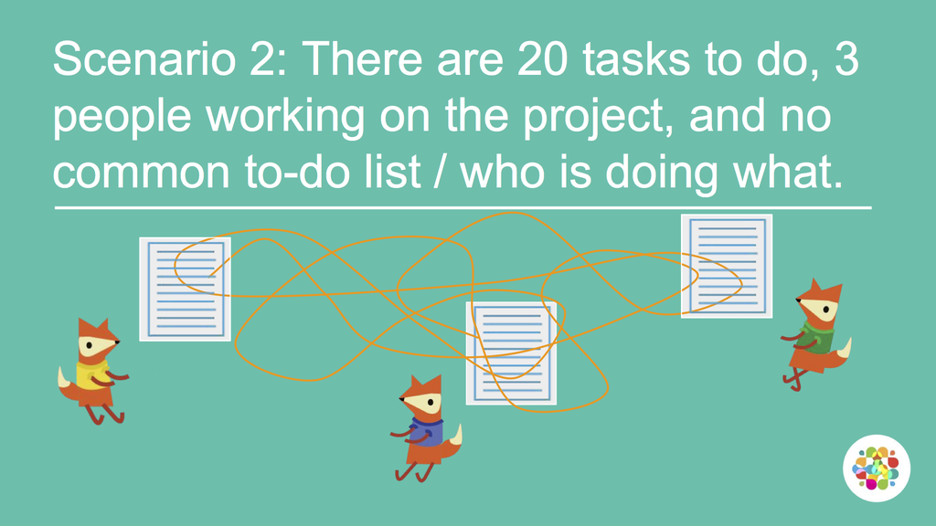

#### **science increasingly computational**

- > demands for increased openness, transparency & reproducibility

#### **science always benefits from collaboration**

- > push to harness the power of the internet

## BUT: succesful modern science workflows

*can be extremely powerful*

[figure not shown]

# GitHub for science

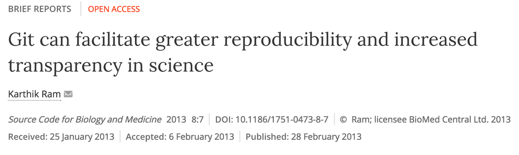

> - ideal for managing the full suite of research outputs such as datasets, statistical code, figures, lab notes, and manuscripts.
> - supports peer review, commenting, and discussion.
> - Diverse range of efforts, from individual to large bioinformatics projects, laboratory repositories, as well as global collaborations have found a home on GitHub

## **Rstudio for r users**

**♡**

# **GitHub features**

>

## remote repositories

centralising information e.g. [**weecology** / *“Nine simple ways to make it easier to (re)use your data” paper*](http://ojs.library.queensu.ca/index.php/IEE/article/view/4608/0)

[figure not shown]

## commits

traceability

[figure not shown]

## issues

project management

[figure not shown]

## graphs

### project & team tracking

tracking contributors

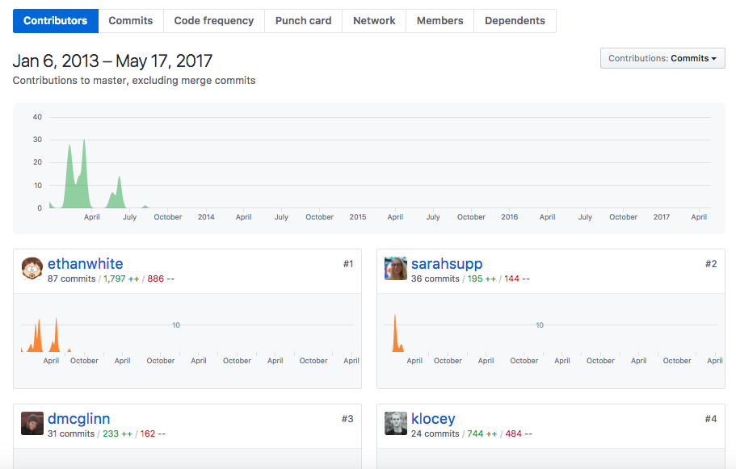

# **entire process of project evolution reproducible**

## **more on github for science**

#### [**Ten Simple Rules for Taking Advantage of Git and GitHub**](https://www.ncbi.nlm.nih.gov/pmc/articles/PMC4945047/)

#### **Github as part of** [**Good Enough Practices in Scientific Computing**](https://arxiv.org/abs/1609.00037)

#### e.g [*My research workflow, based on Github*](https://status.github.com/images/invertocat.png) by [*Carl Boettiger*](https://twitter.com/cboettig)

## **Example `GitHub` uses**

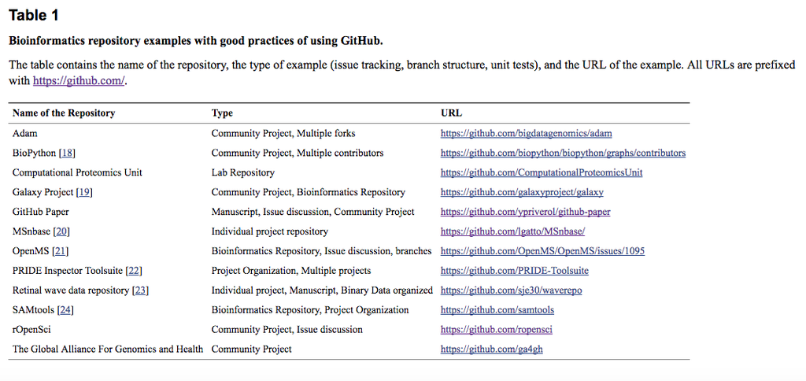

https://www.ncbi.nlm.nih.gov/pmc/articles/PMC4945047/

## **Practical: Github & Rstudio for collaborative coding**

### **#EvoLottery**

**Beak and skull shapes in birds of prey (“raptors”) are strongly coupled and largely controlled by size.**

- In this exercise, each participant will **fork a github repo**, and **contribute a file** required to simulate the *evolutionary trajectory of an imaginary species’ body size*.
- We’ll use **github** to **collate all species files** and **plot** them all up together at the end! We’ll also **discover the skull and beak shapes** associated with each simulated species size.

### [**Enter Practical**](http://annakrystalli.me/ACCE/evolottery.html)

http://annakrystalli.me/ACCE/evolottery.html

## RECAP Forking

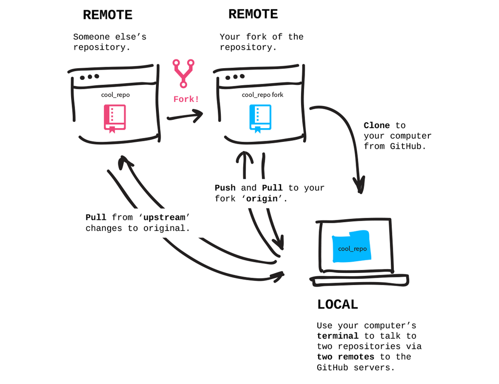

# Back to our project.

We’ve initiated our project as a github repository but not connected it to remote repository on **GitHub**

In the **Evolottery** exercise we used a method of linking to a repository by **cloning** one that **already exists on GitHub**. Now we want to do the opposite.

```r
usethis::use_github(protocol = "https")
```

(Works with GITHUB_PAT)

*if for some reason it creates the repository on GitHub but doesn’t push the contents, try running* `git push origin master` *in the terminal/shell*

#### Authentication problems

If you create the github reporsitory with **ssh** authentication (`use_github()` default), you can:

1. [Set up an ssh key](https://help.github.com/enterprise/2.13/user/articles/generating-a-new-ssh-key-and-adding-it-to-the-ssh-agent/)
2. Change to *https* authentication :

   ```
   git remote set-url origin https://github.com/USERNAME/REPOSITORY.git
   ```

Check what authentication you are using by running this in the terminal

```
git remote -v
```

*https*: `origin https://github.com/USERNAME/REPOSITORY.git (fetch)`

*ssh*: `origin git@github.com:USERNAME/REPOSITORY.git (push)`

More details [here](https://help.github.com/articles/changing-a-remote-s-url/)

There are **two very important documents missing in our repository**

1. A README
2. A License

Let’s go create an issue in our repository about this.

#### README

READMEs are the landing page of any repository on GitHub.

```r
usethis::use_readme_md()
```

Creates a simple **`md`** README

```r
usethis::use_readme_rmd()
```

Creates an **`Rmd`** README in which you can run R examples and automatically creates the `README.md`. - Render each time you make changes to `README.Rmd` so `README.md` is updated.

### License

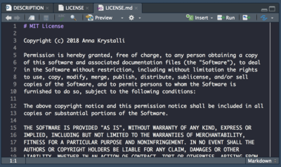

```r
usethis::use_mit_license("Anna Krystalli")
```

### Referencing an issue in a commit message

#### You can **reference a specific issue using `#`** in a commit message to link it to that specific issue.

eg `add README & LICENSE. Fix #1`

- **Commit all these files** that you just created, **referencing issue 1 (`#1`) in your commit message**.
- **Push** to GitHub
- Check out the issue to se what happened.

(N.B if you use the phrase **resolve #1**, GitHub will also close the issue 👍)

## Publishing html to GitHub.

- If you haven’t already published the rendered (.`html`) version of your report do so now.
- Head to GitHub and look for the **Settings** ⚙️
- Scroll down to the **GitHub Pages** Section and set the **Source** to **`master branch`**.

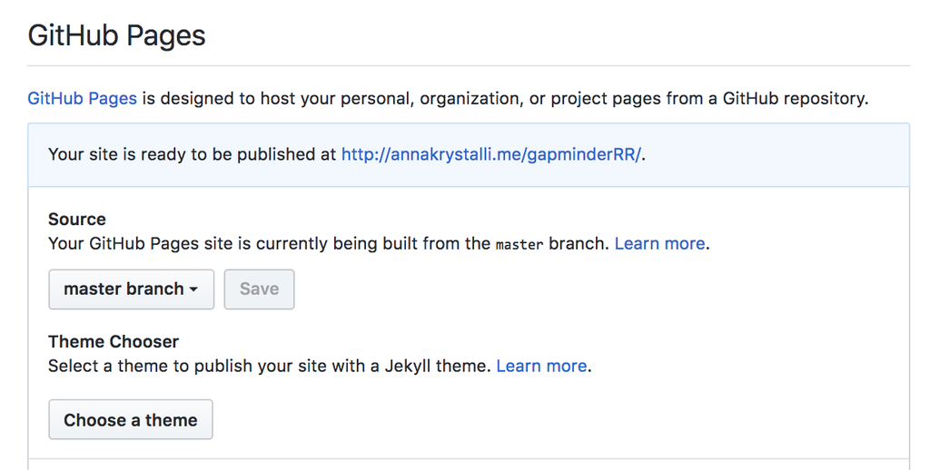

Your repo is now hosting any html documents at the address given!

The URL will be the URL given followed by the name of the file:

http://annakrystalli.me/gapminderRR/gapminder-analysis.html

# Recap

## GitHub amazing for:

- **fostering reproducibility**
- **empowering collaboration**

## GitHub tips

- Use [README](https://github.com/matiassingers/awesome-readme) to provide an overview of your project
- use issues to keep track of bugs, tasks, and enhancements
- include a [LICENSE](https://github.com/blog/1530-choosing-an-open-source-license)
- practice by collaborating with yourself on different machines!
- [handy github glossary](https://help.github.com/enterprise/11.10.340/user/articles/github-glossary/)